# Incidencia Delictiva Estatal

(México 2015 - 2025)

Méndez Ávila Luis Geovanni

lgma77@ciencias.unam.mx

Paredes Zamudio Luis Daniel

danielparedes@ciencias.unam.mx

Sánchez Rosas Roberto Samuel

samuel03srciencias.unam.mx

México sufre de un serio problema de delicuencia. Y esto, desgraciadamente, no ha disminuido considerablemente en 10 años a la fecha.

Al analizar datos sobre la incidencia delictiva en el país, con foco en 2015 a 2025, y tomando en cuenta los datos obtenidos desde la [Plataforma Nacional de Datos Abiertos Méxicana](https://www.datos.gob.mx/dataset/incidencia_delictiva/resource/d9b2792a-33a2-4ea8-8527-210d9e99de5e) queremos resolver la siguiente pregunta:

# ¿Se puede predecir la incidencia delictiva en México?

**Código**

```python
import sys
from pathlib import Path

sys.path.insert(0, str(Path.cwd().parent))

import pandas as pd
import matplotlib.pyplot as plt
import matplotlib.dates as mdates
import seaborn as sns

from src import config
from src.data import DataRepository
from src.preprocessing import PreprocessingPipeline
from src.eda import StatisticsAnalyzer, OutlierDetector

sns.set_theme(style=config.SEABORN_THEME, palette=config.PLOT_PALETTE)
pd.set_option("display.max_columns", 20)
pd.set_option("display.width", 140)
pd.set_option("display.max_colwidth", 200)

repo = DataRepository()
dataframe = repo.load()
repo.dictionary()
```

|  | columna | tipo | descripcion |
| --- | --- | --- | --- |
| 0 | anio | int64 | Año de registro de las averiguaciones previas y/o carpetas de investigación. |
| 1 | clave_ent | int64 | Clave de la entidad, según el Marco Geoestadístico Nacional (MGN) del Instituto Nacional de Geografía y Estadística (INEGI). |
| 2 | entidad | str | Entidad federativa de registro de las averiguaciones previas y/o carpetas de investigación. |
| 3 | bien_juridico_afectado | str | Primera clasificación de los delitos en las averiguaciones previas y/o carpetas de investigación. (Patrimonio, vida, libertad, etc.) |
| 4 | tipo_delito | str | Segunda clasificación de los delitos. (Falsedad, Lesiones, Robo, etc.) |
| 5 | subtipo_delito | str | Tercera clasificación de los delitos. Subcategorías específicas de cada tipo de delito. (Lesiones dolosas, etc. Puede ser repetido con la anterior) |
| 6 | modalidad | str | Cuarta clasificación de los delitos. Forma en la que se comete el delito. (Con violencia, sin violencia, etc.) |
| 7 | mes | str | Mes de registro de las averiguaciones previas y/o carpetas de investigación. |
| 8 | fecha | str | Fecha de registro de las averiguaciones previas y/o carpetas de investigación. |
| 9 | incidencia_delictiva | int64 | Incidencia delictiva del Fuero Común (Número absoluto de presuntos delitos registrados) |
| 10 | entidad_federativa | str | Entidad federativa de registro de las averiguaciones previas y/o carpetas de investigación. |

**Código**

```python
dataframe.head(5)
```

|  | anio | clave_ent | entidad | bien_juridico_afectado | tipo_delito | subtipo_delito | modalidad | mes | fecha | incidencia_delictiva | entidad_federativa |
| --- | --- | --- | --- | --- | --- | --- | --- | --- | --- | --- | --- |
| 0 | 2015 | 1 | Aguascalientes | El patrimonio | Abuso de confianza | Abuso de confianza | Abuso de confianza | Abril | 2015-04-01 | 22 | Aguascalientes |
| 1 | 2015 | 1 | Aguascalientes | El patrimonio | Abuso de confianza | Abuso de confianza | Abuso de confianza | Agosto | 2015-08-01 | 40 | Aguascalientes |
| 2 | 2015 | 1 | Aguascalientes | El patrimonio | Abuso de confianza | Abuso de confianza | Abuso de confianza | Diciembre | 2015-12-01 | 26 | Aguascalientes |
| 3 | 2015 | 1 | Aguascalientes | El patrimonio | Abuso de confianza | Abuso de confianza | Abuso de confianza | Enero | 2015-01-01 | 41 | Aguascalientes |
| 4 | 2015 | 1 | Aguascalientes | El patrimonio | Abuso de confianza | Abuso de confianza | Abuso de confianza | Febrero | 2015-02-01 | 33 | Aguascalientes |

- 413,952 registros que abarcan desde enero de 2015 hasta diciembre de 2025 (11 años).
- 32 entidades × 40+ tipos de delito × 132 meses lo que nos permite hacer análisis longitudinales de la evolución del delito en cada estado.

Haremos lo siguiente con el dataset original:

- Borraremos las columnas año y mes para poder trabajar únicamente con fecha, la cual tranformamos a datatime
- `entidad_federativa` es un duplicado de `entidad`, por lo que borramos ésta columna.
- `clave_entidad` no nos es de útilidad al ya tener el nombre de las entidades, por lo que borramos ésta columna.
- Analizamos el dataset en busca de duplicados y valores nulos.
- Consideraremos que una entrada es inválida si tiene valores NaN en `incidencia_delictiva`, `fecha` y `entidad`. Una vez detectadas, serán eliminadas.

### Estadísticas Descriptivas Numéricas

**Código**

```python
repo = DataRepository("../data/processed/INM_estatal_dic25_clean.csv")
dataframe = repo.load()
stats = StatisticsAnalyzer(dataframe)
stats.numeric_stats()
```

|  | columna | Promedio | Mediana | Desviacíon Estándar | Valor Mínimo | Q1 | Q3 | Valor Máximo | range |
| --- | --- | --- | --- | --- | --- | --- | --- | --- | --- |
| 0 | incidencia_delictiva | 52.499106 | 2.0 | 204.518424 | 0.0 | 0.0 | 26.0 | 9968.0 | 9968.0 |

**Código**

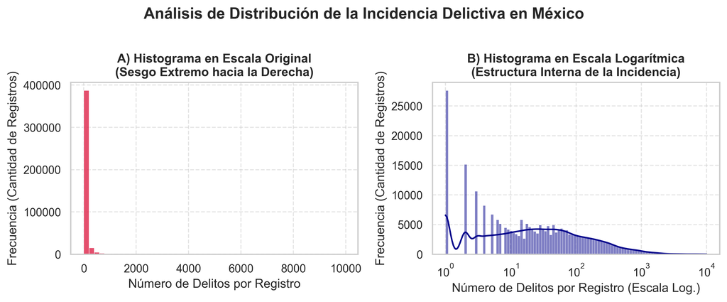

```python
fig, axes = plt.subplots(1, 2, figsize=(10, 4))

sns.histplot(
    data=dataframe,
    x="incidencia_delictiva",
    bins=50,
    color="crimson",
    ax=axes[0]
)
axes[0].set_title("A) Histograma en Escala Original\n(Sesgo Extremo hacia la Derecha)", fontsize=12, fontweight="bold")
axes[0].set_xlabel("Número de Delitos por Registro")
axes[0].set_ylabel("Frecuencia (Cantidad de Registros)")
axes[0].grid(True, linestyle="--", alpha=0.5)

df_non_zero = dataframe[dataframe["incidencia_delictiva"] > 0]
sns.histplot(
    data=df_non_zero,
    x="incidencia_delictiva",
    kde=True,
    log_scale=True,
    color="darkblue",
    ax=axes[1]
)
axes[1].set_title("B) Histograma en Escala Logarítmica\n(Estructura Interna de la Incidencia)", fontsize=12, fontweight="bold")
axes[1].set_xlabel("Número de Delitos por Registro (Escala Log.)")
axes[1].set_ylabel("Frecuencia (Cantidad de Registros)")
axes[1].grid(True, linestyle="--", alpha=0.5)

plt.suptitle("Análisis de Distribución de la Incidencia Delictiva en México", fontsize=15, fontweight="bold", y=1.02)
plt.tight_layout()
plt.show()
```

### Estadísticas Descriptivas Categóricas

**Código**

```python
stats.categorical_stats()
```

|  | columna | valores únicos | moda | frecuencia modal |
| --- | --- | --- | --- | --- |
| 0 | fecha | 132 | 2015-04-01 | 3136 |
| 1 | entidad | 32 | Aguascalientes | 12936 |
| 2 | bien_juridico_afectado | 7 | El patrimonio | 177408 |
| 3 | tipo_delito | 40 | Robo | 152064 |
| 4 | subtipo_delito | 55 | Robo de maquinaria | 25344 |
| 5 | modalidad | 59 | Con violencia | 50688 |

### Delitos más Comunes

**Código**

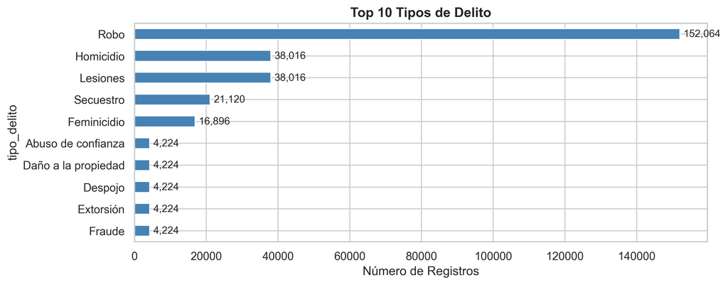

Delitos más Comunes en México (2015-2025)

```python
crime_counts = dataframe["tipo_delito"].value_counts().head(10)

fig, ax = plt.subplots(figsize=(10, 4))
crime_counts.plot(kind="barh", ax=ax, color="steelblue")
ax.set_title("Top 10 Tipos de Delito", fontsize=13, fontweight="bold")
ax.set_xlabel("Número de Registros")
ax.invert_yaxis()

# Añade valores en las barras
for i, v in enumerate(crime_counts.values):
    ax.text(v + 1000, i, f"{v:,}", va="center", fontsize=10)

plt.tight_layout()
plt.show()
```

### Incidencia Delictiva por Estado

**Código**

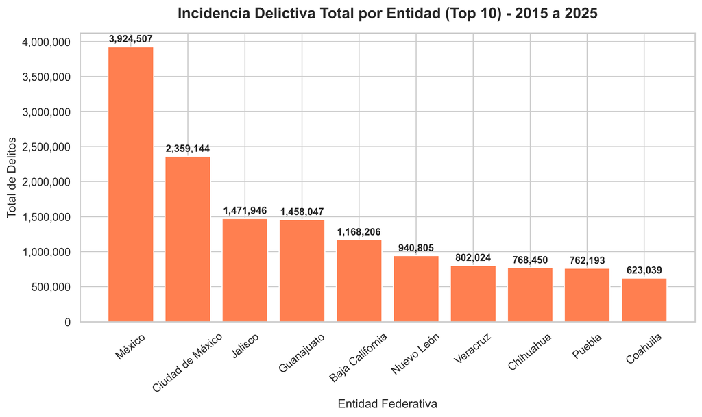

Incidencia Delictiva Total por Estado (2015-2025)

```python
from matplotlib.ticker import StrMethodFormatter

entidad_counts = (
    dataframe.groupby("entidad")["incidencia_delictiva"]
    .sum()
    .sort_values(ascending=False)
    .head(10)
)

fig, ax = plt.subplots(figsize=(10, 6))
bars = ax.bar(entidad_counts.index, entidad_counts.values, color="coral")
# Formato del eje Y con separadores de miles y sin decimales
ax.yaxis.set_major_formatter(StrMethodFormatter("{x:,.0f}"))
# Agregamos los valores reales arriba de cada barra con separadores de miles
ax.bar_label(bars, fmt="{:,.0f}", padding=3, fontsize=10, fontweight="bold")

ax.set_title(
    "Incidencia Delictiva Total por Entidad (Top 10) - 2015 a 2025",
    fontsize=15,
    fontweight="bold",
    pad=15,
)
ax.set_ylabel("Total de Delitos", fontsize=12)
ax.set_xlabel("Entidad Federativa", fontsize=12)
ax.tick_params(axis="x", rotation=40)

plt.tight_layout()
plt.show()
```

### Bienes Jurídicos más Afectados

**Código**

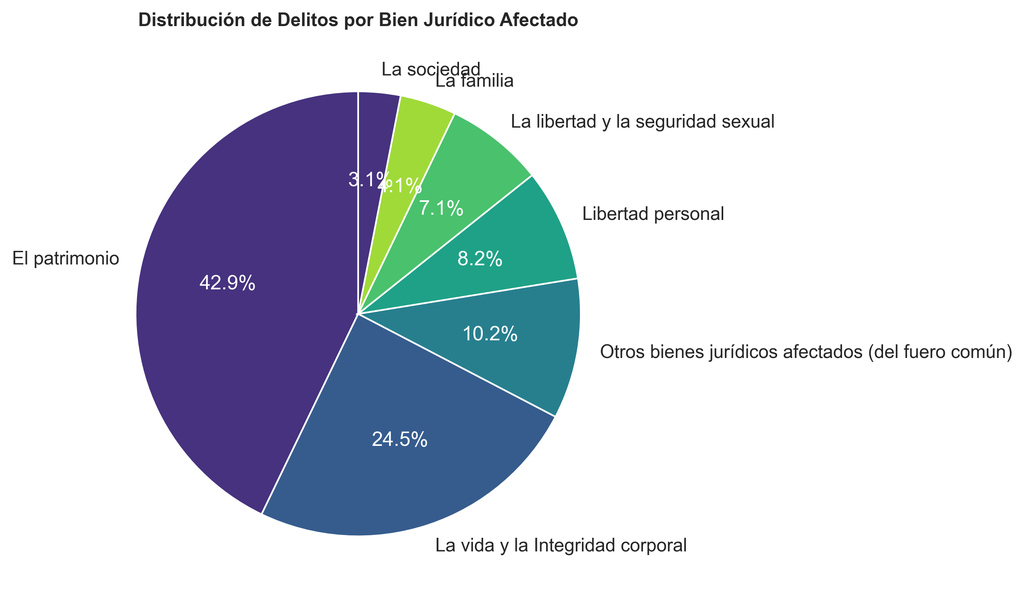

Bienes Jurídicos más Afectados por Delitos en México (2015-2025)

```python
bien_juridico = dataframe["bien_juridico_afectado"].value_counts()

fig, ax = plt.subplots(figsize=(6, 6))
wedges, texts, autotexts = ax.pie(
    bien_juridico.values, labels=bien_juridico.index, autopct="%1.1f%%", startangle=90
)
ax.set_title(
    "Distribución de Delitos por Bien Jurídico Afectado", fontsize=11, fontweight="bold"
)
for autotext in autotexts:
    autotext.set_color("white")

plt.show()
```

### Delincuencia por Año

**Código**

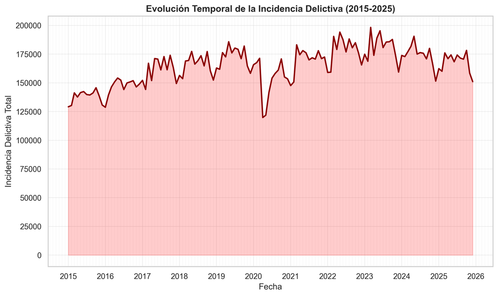

Incidencia Delictiva por Año en México (2015-2025)

```python
dataframe["fecha"] = pd.to_datetime(dataframe["fecha"])  # add this line before groupby
temporal = dataframe.groupby("fecha")["incidencia_delictiva"].sum().sort_index()

fig, ax = plt.subplots(figsize=(10, 6))
ax.plot(temporal.index, temporal.values, linewidth=2, color="darkred")
ax.fill_between(temporal.index, temporal.values, alpha=0.2, color="red")

ax.set_title(
    "Evolución Temporal de la Incidencia Delictiva (2015-2025)",
    fontsize=13,
    fontweight="bold",
)
ax.set_xlabel("Fecha")
ax.set_ylabel("Incidencia Delictiva Total")
ax.grid(True, alpha=0.2)
ax.xaxis.set_major_locator(mdates.YearLocator())
ax.xaxis.set_major_formatter(mdates.DateFormatter("%Y"))
ax.xaxis.set_minor_locator(mdates.MonthLocator())
ax.grid(True, which="major", alpha=0.3)
ax.grid(True, which="minor", alpha=0.1)
plt.tight_layout()
plt.show()
```

### Detección de Outliers

Para detectar outliers lo que haremos será ocupar IQR. Por lo anterior notamos que la incidencia delictiva está fuertemente sesgada a la derecha por la CDMX y Edomex, ya que disparan los valores frente a estados pequeños. El z-score asume normalidad y los propios extremos inflan media y desviación, así que ocupar ésta medida reportaría resultados sesgados.

Para esto lo que haremos será ocupar la clase `OutlierDetector` que, como su nombre lo indica, identificará los valores atípicos y luego usaremos su método `flag()` para aplicar ésta identificación a un nuevo dataframe.

**Código**

```python
det = OutlierDetector(dataframe, columns=["incidencia_delictiva"])
det.summary()
```

|  | columna | n_total | min | max | lower | upper | n_outliers | pct_outliers |
| --- | --- | --- | --- | --- | --- | --- | --- | --- |
| 0 | incidencia_delictiva | 413952 | 0.0 | 9968.0 | -39.0 | 65.0 | 63128 | 15.250077 |

**Código**

```python
det.flag().tail(1)
```

|  | fecha | entidad | bien_juridico_afectado | tipo_delito | subtipo_delito | modalidad | incidencia_delictiva | incidencia_delictiva_is_outlier |
| --- | --- | --- | --- | --- | --- | --- | --- | --- |
| 413951 | 2025-09-01 | Zacatecas | Otros bienes jurídicos afectados (del fuero común) | Otros delitos del Fuero Común | Otros delitos del Fuero Común | Otros delitos del Fuero Común | 133 | True |

### Modelo Predictivo

Ahora, lo que buscamos es construir un modelo de regresión capaz de predecir la incidencia delictiva mensual a nivel estatal en México, utilizando como variables predictoras la entidad federativa, el bien jurídico afectado, el tipo y subtipo de delito, la modalidad y *features* temporales (año, mes, trimestre).

Para esto utilizaremos un **Random Forest Regressor** dentro de un pipeline de scikit-learn que incluye lo siguiente:

- **Preprocesamiento**: codificación One-Hot de variables categóricas y estandarización de variables numéricas.
- **Búsqueda de hiperparámetros**: Usaremos `RandomizedSearchCV` con validación cruzada de 3 pliegues, más eficiente que una búsqueda exhaustiva para este volumen de datos.
- **Transformación del objetivo**: Aplicaremos `log1p` a la variable objetivo para mitigar el sesgo observado en el EDA.

### Datos y Preprocesamiento

- **Muestra estratificada**: 50,000 registros de ~414,000 (preserva proporción de tipos de delito)
- **Split**: 80% train / 20% test
- **Pipeline**: OneHotEncoder (categóricas) + StandardScaler (numéricas)
- **Target**: `log1p(incidencia_delictiva)` para mitigar sesgo a la derecha

**Código**

```python
import sys
from pathlib import Path

sys.path.insert(0, str(Path.cwd().parent))

import pandas as pd
import numpy as np
import matplotlib.pyplot as plt
import seaborn as sns

from sklearn.model_selection import train_test_split

from src.model.preprocesamiento import (
    cargar_preparar_datos,
    separar_features_target,
    construir_preprocesador,
)
from src.model.entrenamiento import entrenar_random_forest
from src.model.evaluacion import evaluar_modelo, grafica_predicciones, grafica_residuales
from src.model.persistencia import guardar_modelo, cargar_modelo
#| label: models-data
RUTA_DATOS = str(Path.cwd().parent / "data" / "processed" / "INM_estatal_dic25_clean.csv")

df = cargar_preparar_datos(RUTA_DATOS)
X, y = separar_features_target(df)
preprocessor = construir_preprocesador(X)

X_train, X_test, y_train, y_test = train_test_split(
    X, y, test_size=0.20, random_state=42
)

print(f"Muestra estratificada: {df.shape[0]:,} filas x {df.shape[1]} columnas")
print(f"Train: {X_train.shape[0]:,} filas | Test: {X_test.shape[0]:,} filas")
print(f"Features: {X.shape[1]} columnas (5 categóricas + 3 numéricas)")
```

```
Muestra estratificada: 50,000 filas x 7 columnas
Train: 40,000 filas | Test: 10,000 filas
Features: 8 columnas (5 categóricas + 3 numéricas)
```

### Entrenamiento y Métricas

Ocuparemos el siguiente espacio de búsqueda:

| Parámetro | Valores |
| --- | --- |
| `n_estimators` | 100, 150 |
| `max_depth` | 15, None (sin límite) |
| `min_samples_split` | 2, 5 |

junto a la siguiente configuración:

- `n_iter=8`: evalúa 8 combinaciones aleatorias de los parámetros.
- `cv=3`: validación cruzada con 3 pliegues.
- `scoring="r2"`: optimiza el coeficiente de determinación R².
- `n_jobs=-1`: utiliza todos los núcleos disponibles del procesador.

**Código**

```python
search = entrenar_random_forest(X_train, y_train, preprocessor)
mejor_modelo = search.best_estimator_

print(f"Mejores parámetros: {search.best_params_}")
print(f"Mejor R² (CV):      {search.best_score_:.4f}")

metricas, y_pred = evaluar_modelo(mejor_modelo, X_test, y_test)
display(metricas)
```

```
Fitting 3 folds for each of 8 candidates, totalling 24 fits
Mejores parámetros: {'model__n_estimators': 150, 'model__min_samples_split': 2, 'model__max_depth': None}
Mejor R² (CV):      0.9201
```

|  | Metrica | Valor |
| --- | --- | --- |
| 0 | MAE | 0.307301 |
| 1 | MSE | 0.262411 |
| 2 | RMSE | 0.512261 |
| 3 | R2 | 0.932790 |

### Análisis gráfico: Real vs Predicho

**Código**

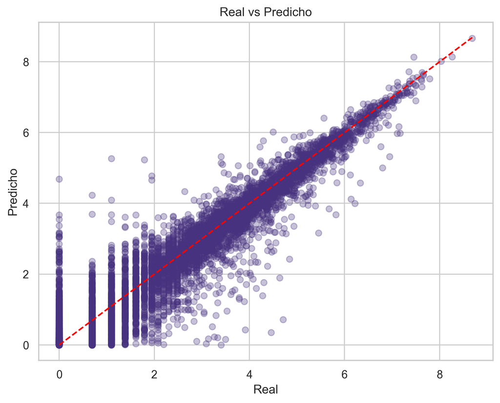

```python
grafica_predicciones(y_test, y_pred)
```

# Clustering y Análisis de Componentes Principales

Ahora buscamos identificar segmentos, perfiles y patrones latentes en la incidencia delictiva de las 32 entidades federativas de México mediante técnicas de agrupamiento no supervisado utilizando K-Means centrandonos en los valores de los posibles siete Bienes Jurídicos Afectados registrados en cada estado.

Queremos resolver la siguiente pregunta:

> *¿Qué tipo de delincuencia predomina en cada entidad federativa y qué estados comparten perfiles delictivos similares?*

**Código**

```python
import sys
from pathlib import Path

sys.path.insert(0, str(Path.cwd().parent))

import pandas as pd
import matplotlib.pyplot as plt
import seaborn as sns

from src import config
from src.data import DataRepository
from src.clustering import CrimeClusteringPipeline

sns.set_theme(style=config.SEABORN_THEME, palette=config.PLOT_PALETTE)

repo = DataRepository(config.PROCESSED_CSV)
dataframe = repo.load()

clustering_pipe = CrimeClusteringPipeline()
matrix_pct = clustering_pipe.fit_transform(dataframe)
```

```
[Clustering] Matriz macro preparada con 32 estados y 7 variables (Bienes Jurídicos).
[Clustering] El plano visual (PCA 2D) captura el 55.32% de la varianza total de estas categorías.
```

### Selección del Número de Clusters

**Código**

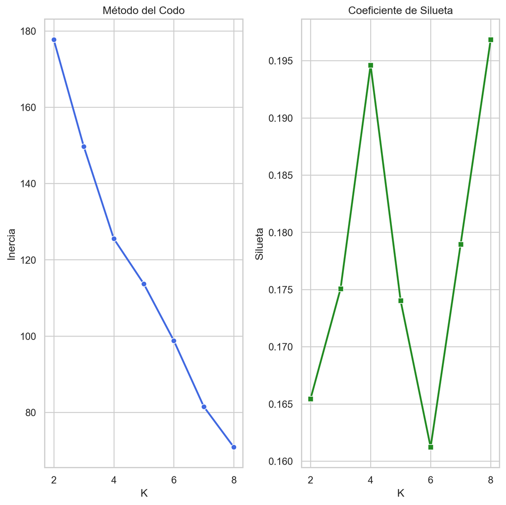

Selección del número de clusters

```python
metrics = clustering_pipe.evaluate_k_options(max_k=8)

fig, axes = plt.subplots(1, 2, figsize=(8, 8), dpi=config.PLOT_DPI)

sns.lineplot(x=metrics["k"], y=metrics["inertia"], marker="o", ax=axes[0], color="royalblue", linewidth=2)
axes[0].set_title("Método del Codo")
axes[0].set_xlabel("K")
axes[0].set_ylabel("Inercia")
axes[0].grid(True)

sns.lineplot(x=metrics["k"], y=metrics["silhouette"], marker="s", ax=axes[1], color="forestgreen", linewidth=2)
axes[1].set_title("Coeficiente de Silueta")
axes[1].set_xlabel("K")
axes[1].set_ylabel("Silueta")
axes[1].grid(True)

plt.tight_layout()
plt.show()
```

### Perfiles Delictivos (K=4)

**Código**

```python
N_CLUSTERS_OPTIMO = 4

df_clusters = clustering_pipe.fit_final_model(n_clusters=N_CLUSTERS_OPTIMO)
matrix_pct = clustering_pipe.prepare_matrix(dataframe)
matrix_pct['cluster'] = df_clusters.set_index('entidad')['cluster']

resumen_clusters = matrix_pct.groupby('cluster').mean()
resumen_porcentual = (resumen_clusters * 100).round(2).T
resumen_porcentual
```

| cluster bien_juridico_afectado | 0 | 1 | 2 | 3 |
| --- | --- | --- | --- | --- |
| El patrimonio | 44.02 | 37.44 | 42.74 | 55.04 |
| La familia | 10.57 | 14.54 | 19.93 | 11.17 |
| La libertad y la seguridad sexual | 3.86 | 2.22 | 3.77 | 2.83 |
| La sociedad | 0.57 | 0.53 | 0.26 | 0.43 |
| La vida y la Integridad corporal | 18.74 | 11.61 | 13.47 | 11.08 |
| Libertad personal | 1.05 | 0.37 | 1.93 | 0.69 |
| Otros bienes jurídicos afectados (del fuero común) | 21.19 | 33.29 | 17.89 | 18.76 |

| Clúster | Perfil Identificado | Entidades Federativas Coincidentes |
| --- | --- | --- |
| **0** | Perfil de Violencia contra las Personas | Campeche, Chiapas, Guerrero, Michoacán, México, Oaxaca |
| **1** | Perfil Diversificado / Otros Bienes Jurídicos | Coahuila, Guanajuato, Tabasco, Yucatán |
| **2** | Perfil Familiar y Libertad Personal | Chihuahua, Durango, Hidalgo, Nayarit, Nuevo León, Quintana Roo, San Luis Potosí, Sinaloa, Sonora, Tamaulipas, Veracruz, Zacatecas |
| **3** | Perfil Patrimonial | Aguascalientes, Baja California, Baja California Sur, CDMX, Colima, Jalisco, Morelos, Puebla, Querétaro, Tlaxcala |

### Proyección PCA (2D)

**Código**

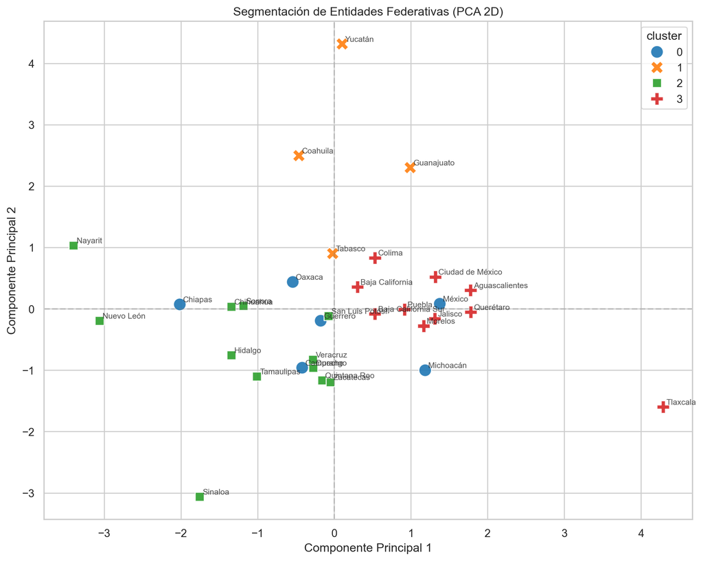

Segmentación de Entidades en 4 Perfiles (PCA 2D)

```python
plt.figure(figsize=(10, 8), dpi=config.PLOT_DPI)

sns.scatterplot(
    data=df_clusters,
    x="pca_1", y="pca_2",
    hue="cluster", palette="tab10",
    s=160, style="cluster", alpha=0.9
)

for i in range(len(df_clusters)):
    plt.text(
        x=df_clusters["pca_1"][i] + 0.04,
        y=df_clusters["pca_2"][i] + 0.04,
        s=df_clusters["entidad"][i],
        fontsize=8, alpha=0.8
    )

plt.title("Segmentación de Entidades Federativas (PCA 2D)")
plt.xlabel("Componente Principal 1")
plt.ylabel("Componente Principal 2")
plt.axhline(0, color="grey", linestyle="--", alpha=0.3)
plt.axvline(0, color="grey", linestyle="--", alpha=0.3)
plt.tight_layout()
plt.show()
```

### Interpretación de la Proyección PCA

| Cluster | Perfil | Posición en PCA | Característica clave |
| --- | --- | --- | --- |
| **#1** | Diversificado | Superior | Mayor participación de “Otros bienes jurídicos” — separación clara del resto |
| **#0 y #2** | Violencia / Familiar | Central | Cercanos entre sí en 2D, pero diferenciados en el espacio original de 7 dimensiones |
| **#3** | Patrimonial | Derecha | Núcleo compacto (CDMX, Jalisco, Querétaro). Tlaxcala aparece aislado |

Anblicks. 2020. «Types of outliers: Key to accurate data analysis». En *Anblicks*. https://www.anblicks.com/blog/an-introduction-to-outliers-what-are-outliers-types-of-outliers/.

«Clustering: Segmentación de Datos para Descubrir Patrones Ocultos». 2026. En *Pontia Tech*. https://www.pontia.tech/clustering-que-es/.

Gaona, Amparo, Gerardo Áviles, y Salvador López. 2021. «Detección de anomalías». En *Minería de datos con R*, 1.ª ed. Las Prensas de Ciencias.

IBM. 2025. «¿Qué es el clustering?» En *IBM*. https://www.ibm.com/es-es/think/topics/clustering.

Pei, Jian. 2026. *Data Mining - Outlier Detection*. https://www2.cs.sfu.ca/CourseCentral/459/jpei/21/459OutlierDetection.pdf.

«¿Qué es el agrupamiento en clústeres k-means?» 2025. En *Google*. Google. https://developers.google.com/machine-learning/clustering/kmeans/overview?hl=es-419#k-means_clustering_algorithm.

Rodríguez, Daniel. 2025. «Método del Codo (elbow method) para seleccionar el número óptimo de clústeres en k-means». En *Analytics Lane*. https://www.analyticslane.com/2023/06/09/metodo-del-codo-elbow-method-para-seleccionar-el-numero-optimo-de- clusteres-en-k-means/.

Sistema Nacional de Seguridad Pública, Secretariado Ejecutivo del. 2025. *Incidencia Delictiva Estatal*. https://www.datos.gob.mx/dataset/incidencia_delictiva/resource/d9b2792a-33a2-4ea8-8527-210d9e99de5e.